# A Future at Risk

## 1 🌍 A Future at Risk: Global Patterns in Adolescent Health and School Infrastructure

In many low-income countries, both **education and adolescent health** are under severe strain. This report visualizes how the lack of basic school infrastructure, such as access to clean drinking water, may intersect with **AIDS-related deaths among girls aged 10–19**.

By analyzing UNICEF data, we highlight countries where: - **School water access is low** - **Adolescent AIDS death rates are high**

These findings aim to guide **policy, investment, and global attention** toward the regions most at risk.

## 2 📉 Water Access vs AIDS Death Rate

This scatterplot examines the relationship between **school water access (%)** and the **rate of AIDS-related deaths among adolescent girls**.

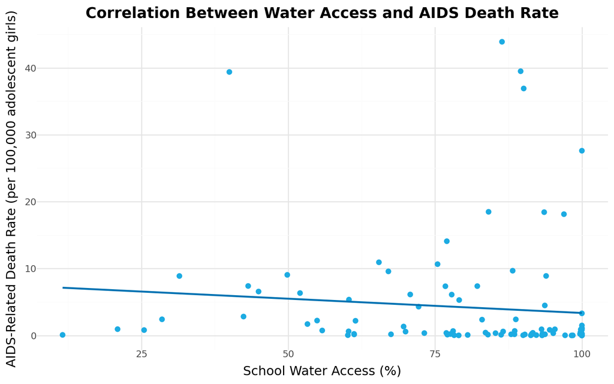

```python
import pandas as pd

# Load the UNICEF datasets
meta = pd.read_csv("unicef_metadata.csv")
ind1 = pd.read_csv("unicef_indicator_1.csv")
ind2 = pd.read_csv("unicef_indicator_2.csv")

# Preview data
meta.head()

# Clean and prepare AIDS data
aids = ind1.copy()
aids = aids[aids['sex'] == 'Female']
aids_latest = aids.sort_values('time_period').groupby('country', as_index=False).last()
aids_latest = aids_latest[['country', 'obs_value']].rename(columns={'obs_value': 'aids_death_rate'})

# Clean and prepare Water Access data
water = ind2.copy()
water_latest = water.sort_values('time_period').groupby('country', as_index=False).last()
water_latest = water_latest[['country', 'obs_value']].rename(columns={'obs_value': 'water_access_pct'})

# Merge both datasets on 'country'
combined = pd.merge(aids_latest, water_latest, on='country')

# Convert to numeric just in case
combined['aids_death_rate'] = pd.to_numeric(combined['aids_death_rate'], errors='coerce')
combined['water_access_pct'] = pd.to_numeric(combined['water_access_pct'], errors='coerce')

# Drop rows with missing values
combined.dropna(inplace=True)

import matplotlib.pyplot as plt
import warnings
from plotnine import *

warnings.filterwarnings('ignore')

# Create scatterplot with regression line
plot = (
    ggplot(combined, aes(x='water_access_pct', y='aids_death_rate')) +
    geom_point(color="#1CABE2", size=2) +
    geom_smooth(method='lm', se=False, color="#0072B2") +
    labs(
        title='Correlation Between Water Access and AIDS Death Rate',
        x='School Water Access (%)',
        y='AIDS-Related Death Rate (per 100,000 adolescent girls)'
    ) +
    theme_minimal() +
    theme(
        plot_title=element_text(size=14, weight='bold'),
        axis_title=element_text(size=12)
    )
)

plot
```

## 3 📊 Bottom 15 Countries by School Water Access

This bar chart highlights the 15 countries with the **lowest access to clean water in schools**.

🚨 These are the areas where: - Students face basic hygiene and health risks - Infrastructure investment is most urgently needed

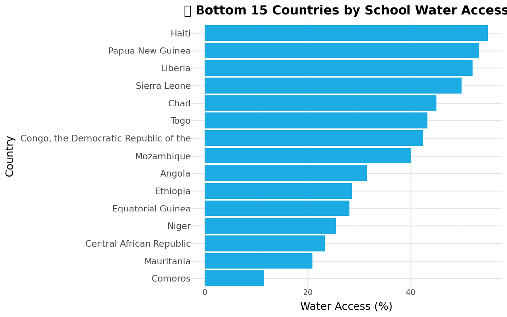

```python
from plotnine import *

# Prepare data
bar_data = water_latest.copy()
bar_data['water_access_pct'] = pd.to_numeric(bar_data['water_access_pct'], errors='coerce')
bar_data = bar_data.dropna().sort_values('water_access_pct').head(15)

# Plot
fill_color = "#1CABE2"

bar_plot = (
    ggplot(bar_data, aes(x='reorder(country, water_access_pct)', y='water_access_pct')) +
    geom_bar(stat='identity', fill=fill_color) +
    coord_flip() +
    labs(
        title='📊 Bottom 15 Countries by School Water Access',
        x='Country',
        y='Water Access (%)'
    ) +
    theme_minimal() +
    theme(
        plot_title=element_text(size=14, weight='bold'),
        axis_text_y=element_text(size=10),
        axis_title=element_text(size=12)
    )
)

bar_plot
```